# 第14节：统计入门（假设检验与接受域分析）

HuangJIn

2026-04-12

# 1 学习目标

- 理解假设检验的数学逻辑：统计量分布、接受域、拒绝域
- 掌握单样本 t、双样本 Welch t、单比例与两比例检验的判定方法
- 能基于“统计量 vs 临界值”做规范结论，而非只机械看 p 值
- 理解样本量对检验显著性的影响

# 2 1. 从样本到检验统计量

统计推断的核心是：在原假设 $H_0$ 成立时，检验统计量 $T(X)$ 的分布已知。  
然后比较“观测统计量”与“临界值”，判断其是否落入拒绝域。

## 2.1 1.1 样本均值的抽样分布

设 $X_1,\dots,X_n$ 独立同分布，
$$E(X_i)=\mu,\quad Var(X_i)=\sigma^2.$$
样本均值 $\bar X$ 满足
$$E(\bar X)=\mu,\quad Var(\bar X)=\frac{\sigma^2}{n}.$$
若总体正态或样本量足够大，$\bar X$ 的分布可近似正态。

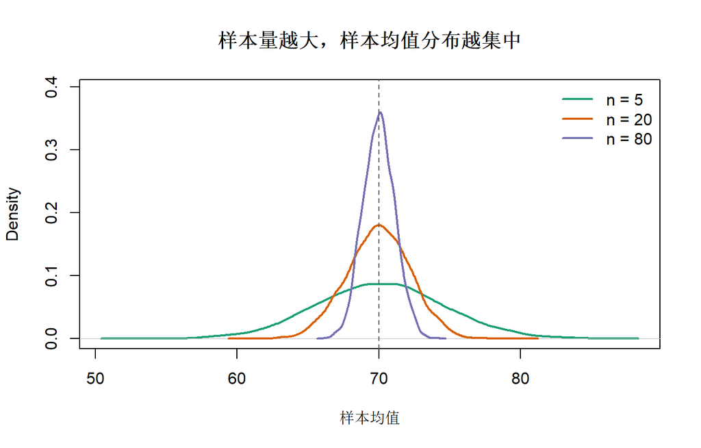

```r
set.seed(20260412)
n_grid <- c(5, 20, 80)
sim_means <- lapply(n_grid, function(n) replicate(4000, mean(rnorm(n, mean = 70, sd = 10))))
cols <- c("#1b9e77", "#d95f02", "#7570b3")

plot(
  density(sim_means[[1]]), col = cols[1], lwd = 2,
  main = "样本量越大，样本均值分布越集中",
  xlab = "样本均值",
  ylim = c(0, max(sapply(sim_means, function(x) max(density(x)$y))) * 1.1)
)
for (i in 2:length(sim_means)) lines(density(sim_means[[i]]), col = cols[i], lwd = 2)
abline(v = 70, lty = 2, col = "gray35")
legend("topright", legend = paste0("n = ", n_grid), col = cols, lwd = 2, bty = "n")
```

# 3 2. 假设检验与接受域

## 3.1 2.1 基本定义

- 原假设：$H_0$
- 备择假设：$H_1$
- 显著性水平：$\alpha$
- 拒绝域：使 $H_0$ 被拒绝的统计量取值集合
- 接受域：拒绝域的补集

决策规则：若 $T_{obs}\in R$（拒绝域），拒绝 $H_0$；否则不拒绝 $H_0$。

## 3.2 2.2 双侧正态检验的接受域示意

双侧 $\alpha=0.05$ 时，临界值为 $\pm z_{0.975}$。
$$A = [-z_{0.975}, z_{0.975}],\quad R =
(-\infty,-z_{0.975})\cup(z_{0.975},\infty).$$

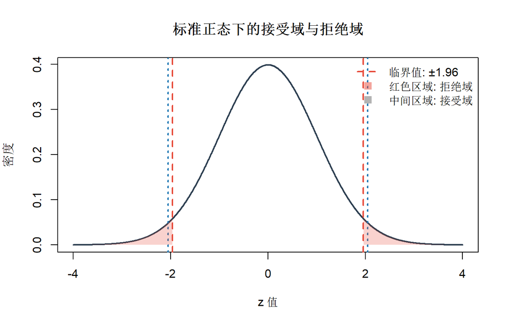

```r
alpha <- 0.05
z_obs <- 2.05
x <- seq(-4, 4, length.out = 2000)
y <- dnorm(x)
crit <- qnorm(1 - alpha / 2)

plot(x, y, type = "l", lwd = 2, col = "#2c3e50",
     main = "标准正态下的接受域与拒绝域",
     xlab = "z 值", ylab = "密度")
abline(v = c(-crit, crit), lty = 2, col = "#e74c3c", lwd = 2)
abline(v = c(-z_obs, z_obs), lty = 3, col = "#1f78b4", lwd = 2)

idx_left <- which(x <= -crit)
idx_right <- which(x >= crit)
polygon(c(x[idx_left], rev(x[idx_left])), c(y[idx_left], rep(0, length(idx_left))),
        col = adjustcolor("#e74c3c", alpha.f = 0.25), border = NA)
polygon(c(x[idx_right], rev(x[idx_right])), c(y[idx_right], rep(0, length(idx_right))),
        col = adjustcolor("#e74c3c", alpha.f = 0.25), border = NA)
legend(
  "topright",
  legend = c(paste0("临界值: ±", round(crit, 3)), "红色区域: 拒绝域", "中间区域: 接受域"),
  lty = c(2, NA, NA), lwd = c(2, NA, NA), pch = c(NA, 15, 15),
  col = c("#e74c3c", adjustcolor("#e74c3c", alpha.f = 0.5), "gray70"),
  pt.cex = 1.4, bty = "n"
)
```

# 4 3. 单样本 t 检验

问题：班级平均分是否高于 70？
$$H_0:\mu=70,\quad H_1:\mu>70,
\quad T=\frac{\bar X-70}{S/\sqrt n}\sim t_{n-1}.$$

接受域与拒绝域（右侧检验）：
$$A=(-\infty, t_{1-\alpha,n-1}],\quad R=(t_{1-\alpha,n-1},\infty).$$

```r
set.seed(42)
score <- round(rnorm(40, mean = 74, sd = 8), 1)

alpha <- 0.05
n1 <- length(score)
mu0 <- 70
xbar <- mean(score)
s <- sd(score)
t_obs <- (xbar - mu0) / (s / sqrt(n1))
t_crit <- qt(1 - alpha, df = n1 - 1)
p_val <- pt(t_obs, df = n1 - 1, lower.tail = FALSE)

one_sample_result <- data.frame(
  n = n1,
  mean = round(xbar, 3),
  t_obs = round(t_obs, 3),
  t_crit = round(t_crit, 3),
  p_value = signif(p_val, 4),
  decision = ifelse(t_obs > t_crit, "拒绝H0", "不拒绝H0")
)
one_sample_result
```

```
##    n  mean t_obs t_crit p_value decision
## 1 40 73.68  2.38  1.685 0.01116   拒绝H0
```

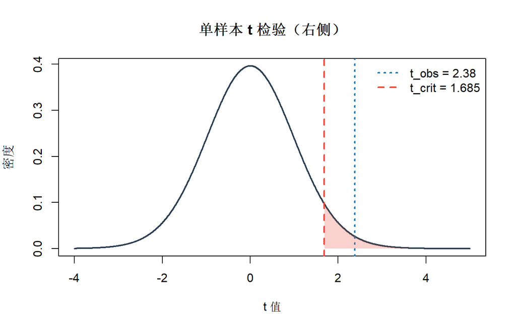

```r
x <- seq(-4, 5, length.out = 2000)
y <- dt(x, df = n1 - 1)
plot(x, y, type = "l", lwd = 2, col = "#2c3e50",
     main = "单样本 t 检验（右侧）",
     xlab = "t 值", ylab = "密度")
abline(v = t_crit, lty = 2, lwd = 2, col = "#e74c3c")
abline(v = t_obs, lty = 3, lwd = 2, col = "#1f78b4")
idx <- which(x >= t_crit)
polygon(c(x[idx], rev(x[idx])), c(y[idx], rep(0, length(idx))),
        col = adjustcolor("#e74c3c", alpha.f = 0.25), border = NA)
legend("topright",
       legend = c(paste0("t_obs = ", round(t_obs, 3)), paste0("t_crit = ", round(t_crit, 3))),
       lty = c(3, 2), lwd = 2, col = c("#1f78b4", "#e74c3c"), bty = "n")
```

教学解释：

- 当 $t_{obs}>t_{crit}$ 时，观测值进入拒绝域，拒绝 $H_0$。
- 本例中均值是否高于 70 分，取决于该判定而非口头描述。

## 4.1 3.1 实际案例：医院质控（住院天数是否低于 7）

$$H_0:\mu=7,\quad H_1:\mu<7,
\quad T=\frac{\bar X-7}{S/\sqrt n}\sim t_{n-1}.$$

左侧检验：
$$A=[t_{\alpha,n-1},\infty),\quad R=(-\infty,t_{\alpha,n-1}).$$

```r
set.seed(2025)
los <- pmax(round(rnorm(60, mean = 6.4, sd = 1.6), 1), 2.5)

n_los <- length(los)
mu0_los <- 7
xbar_los <- mean(los)
s_los <- sd(los)
t_obs_los <- (xbar_los - mu0_los) / (s_los / sqrt(n_los))
t_crit_los <- qt(alpha, df = n_los - 1)
p_los <- pt(t_obs_los, df = n_los - 1)

data.frame(
  n = n_los,
  mean_los = round(xbar_los, 3),
  t_obs = round(t_obs_los, 3),
  t_crit = round(t_crit_los, 3),
  p_value = signif(p_los, 4),
  decision = ifelse(t_obs_los < t_crit_los, "拒绝H0", "不拒绝H0")
)
```

```
##    n mean_los  t_obs t_crit p_value decision
## 1 60    6.615 -1.931 -1.671 0.02912   拒绝H0
```

# 5 4. 两独立样本 Welch t 检验

$$H_0:\mu_A-\mu_B=0,\quad H_1:\mu_A-\mu_B\neq 0.$$

统计量：
$$T=\frac{(\bar X_A-\bar X_B)-0}{\sqrt{S_A^2/n_A+S_B^2/n_B}}.$$

双侧检验接受域：
$$A=[-t_{1-\alpha/2,\nu}, t_{1-\alpha/2,\nu}],
\quad R=\{|T|>t_{1-\alpha/2,\nu}\}.$$

```r
set.seed(123)
group_A <- rnorm(35, mean = 78, sd = 7)
group_B <- rnorm(33, mean = 74, sd = 7)

nA <- length(group_A); nB <- length(group_B)
mA <- mean(group_A); mB <- mean(group_B)
sA2 <- var(group_A); sB2 <- var(group_B)

se_diff <- sqrt(sA2 / nA + sB2 / nB)
t_obs2 <- (mA - mB) / se_diff
nu <- (sA2 / nA + sB2 / nB)^2 / ((sA2 / nA)^2 / (nA - 1) + (sB2 / nB)^2 / (nB - 1))
t_crit2 <- qt(1 - alpha / 2, df = nu)
p2 <- 2 * pt(abs(t_obs2), df = nu, lower.tail = FALSE)

data.frame(
  n_A = nA,
  n_B = nB,
  mean_A = round(mA, 3),
  mean_B = round(mB, 3),
  t_obs = round(t_obs2, 3),
  t_crit = round(t_crit2, 3),
  p_value = signif(p2, 4),
  decision = ifelse(abs(t_obs2) > t_crit2, "拒绝H0", "不拒绝H0")
)
```

```
##   n_A n_B mean_A mean_B t_obs t_crit  p_value decision
## 1  35  33 78.263 74.187 2.713  1.997 0.008517   拒绝H0
```

## 5.1 4.1 实际案例：电商 A/B 停留时长

```r
set.seed(2026)
dwell_A <- rnorm(400, mean = 82, sd = 28)
dwell_B <- rnorm(410, mean = 86, sd = 29)

nA2 <- length(dwell_A); nB2 <- length(dwell_B)
mA2 <- mean(dwell_A); mB2 <- mean(dwell_B)
sA2_2 <- var(dwell_A); sB2_2 <- var(dwell_B)

se_ab <- sqrt(sA2_2 / nA2 + sB2_2 / nB2)
t_obs_ab <- (mB2 - mA2) / se_ab
nu_ab <- (sA2_2 / nA2 + sB2_2 / nB2)^2 / ((sA2_2 / nA2)^2 / (nA2 - 1) + (sB2_2 / nB2)^2 / (nB2 - 1))
t_crit_ab <- qt(1 - alpha / 2, df = nu_ab)
p_ab <- 2 * pt(abs(t_obs_ab), df = nu_ab, lower.tail = FALSE)

data.frame(
  mean_B_minus_A = round(mB2 - mA2, 3),
  t_obs = round(t_obs_ab, 3),
  t_crit = round(t_crit_ab, 3),
  p_value = signif(p_ab, 4),
  decision = ifelse(abs(t_obs_ab) > t_crit_ab, "拒绝H0", "不拒绝H0")
)
```

```
##   mean_B_minus_A t_obs t_crit p_value decision
## 1          4.813 2.433  1.963 0.01517   拒绝H0
```

# 6 5. 比例检验

## 6.1 5.1 单比例右侧检验

$$H_0:p=p_0,\quad H_1:p>p_0,
\quad Z=\frac{\hat p-p_0}{\sqrt{p_0(1-p_0)/n}}\approx N(0,1).$$

接受域：$( -\infty, z_{1-\alpha}]$，拒绝域：$(z_{1-\alpha},\infty)$。

```r
success <- 68
n <- 110
p0 <- 0.5
phat <- success / n
z_obs <- (phat - p0) / sqrt(p0 * (1 - p0) / n)
z_crit <- qnorm(1 - alpha)
p_prop <- pnorm(z_obs, lower.tail = FALSE)

data.frame(
  phat = round(phat, 4),
  z_obs = round(z_obs, 3),
  z_crit = round(z_crit, 3),
  p_value = signif(p_prop, 4),
  decision = ifelse(z_obs > z_crit, "拒绝H0", "不拒绝H0")
)
```

```
##     phat z_obs z_crit  p_value decision
## 1 0.6182 2.479  1.645 0.006588   拒绝H0
```

## 6.2 5.2 两比例双侧检验（临床缓解率）

$$H_0:p_1=p_2,\quad H_1:p_1\neq p_2.$$

合并比例
$$\hat p=\frac{X_1+X_2}{n_1+n_2},$$
统计量
$$Z=\frac{\hat p_2-\hat p_1}{\sqrt{\hat p(1-\hat
p)\left(\frac1{n_1}+\frac1{n_2}\right)}}\approx N(0,1).$$

```r
resp <- c(54, 68)
total <- c(120, 118)

p1 <- resp[1] / total[1]
p2 <- resp[2] / total[2]
p_pool <- sum(resp) / sum(total)

z_obs2 <- (p2 - p1) / sqrt(p_pool * (1 - p_pool) * (1 / total[1] + 1 / total[2]))
z_crit2 <- qnorm(1 - alpha / 2)
p_2prop <- 2 * pnorm(abs(z_obs2), lower.tail = FALSE)

data.frame(
  p_old = round(p1, 4),
  p_new = round(p2, 4),
  diff = round(p2 - p1, 4),
  z_obs = round(z_obs2, 3),
  z_crit = round(z_crit2, 3),
  p_value = signif(p_2prop, 4),
  decision = ifelse(abs(z_obs2) > z_crit2, "拒绝H0", "不拒绝H0")
)
```

```
##   p_old  p_new   diff z_obs z_crit p_value decision
## 1  0.45 0.5763 0.1263 1.949   1.96 0.05135 不拒绝H0
```

# 7 6. 接受域与拒绝域的统一判定

## 7.1 6.1 判定模板

1. 写出 $H_0,H_1$
2. 写出统计量及其在 $H_0$ 下分布
3. 给出临界值与接受域
4. 代入观测值，判断是否进入拒绝域

## 7.2 6.2 结果总表（无区间指标）

```r
summary_table <- data.frame(
  case = c(
    "班级均值 > 70（单样本t）",
    "住院天数 < 7（单样本t）",
    "A/B学习组均值差（Welch t）",
    "电商B版停留时长（Welch t）",
    "单组有效率 > 50%（单比例）",
    "临床两组缓解率差异（两比例）"
  ),
  statistic = c(t_obs, t_obs_los, t_obs2, t_obs_ab, z_obs, z_obs2),
  critical_value = c(t_crit, t_crit_los, t_crit2, t_crit_ab, z_crit, z_crit2),
  p_value = c(p_val, p_los, p2, p_ab, p_prop, p_2prop),
  decision = c(
    ifelse(t_obs > t_crit, "拒绝H0", "不拒绝H0"),
    ifelse(t_obs_los < t_crit_los, "拒绝H0", "不拒绝H0"),
    ifelse(abs(t_obs2) > t_crit2, "拒绝H0", "不拒绝H0"),
    ifelse(abs(t_obs_ab) > t_crit_ab, "拒绝H0", "不拒绝H0"),
    ifelse(z_obs > z_crit, "拒绝H0", "不拒绝H0"),
    ifelse(abs(z_obs2) > z_crit2, "拒绝H0", "不拒绝H0")
  )
)

summary_table$statistic <- round(summary_table$statistic, 3)
summary_table$critical_value <- round(summary_table$critical_value, 3)
summary_table$p_value <- signif(summary_table$p_value, 4)
summary_table
```

```
##                           case statistic critical_value  p_value decision
## 1     班级均值 > 70（单样本t）     2.380          1.685 0.011160   拒绝H0
## 2      住院天数 < 7（单样本t）    -1.931         -1.671 0.029120   拒绝H0
## 3   A/B学习组均值差（Welch t）     2.713          1.997 0.576300   拒绝H0
## 4   电商B版停留时长（Welch t）     2.433          1.963 0.015170   拒绝H0
## 5   单组有效率 > 50%（单比例）     2.479          1.645 0.006588   拒绝H0
## 6 临床两组缓解率差异（两比例）     1.949          1.960 0.051350 不拒绝H0
```

# 8 7. 大样本下的小效应

当样本量增大时，标准误下降，统计量可能增大；因此“小效应也可能显著”。

```r
set.seed(2026)
n_big <- 5000
x1 <- rnorm(n_big, mean = 100, sd = 15)
x2 <- rnorm(n_big, mean = 99.4, sd = 15)

m_diff <- mean(x1) - mean(x2)
se_big <- sqrt(var(x1) / n_big + var(x2) / n_big)
t_big <- m_diff / se_big
nu_big <- (var(x1) / n_big + var(x2) / n_big)^2 / ((var(x1) / n_big)^2 / (n_big - 1) + (var(x2) / n_big)^2 / (n_big - 1))
t_crit_big <- qt(1 - alpha / 2, df = nu_big)
p_big <- 2 * pt(abs(t_big), df = nu_big, lower.tail = FALSE)

data.frame(
  mean_diff = round(m_diff, 4),
  t_obs = round(t_big, 3),
  t_crit = round(t_crit_big, 3),
  p_value = signif(p_big, 4),
  decision = ifelse(abs(t_big) > t_crit_big, "拒绝H0", "不拒绝H0")
)
```

```
##   mean_diff t_obs t_crit p_value decision
## 1    0.2481 0.826   1.96   0.409 不拒绝H0
```

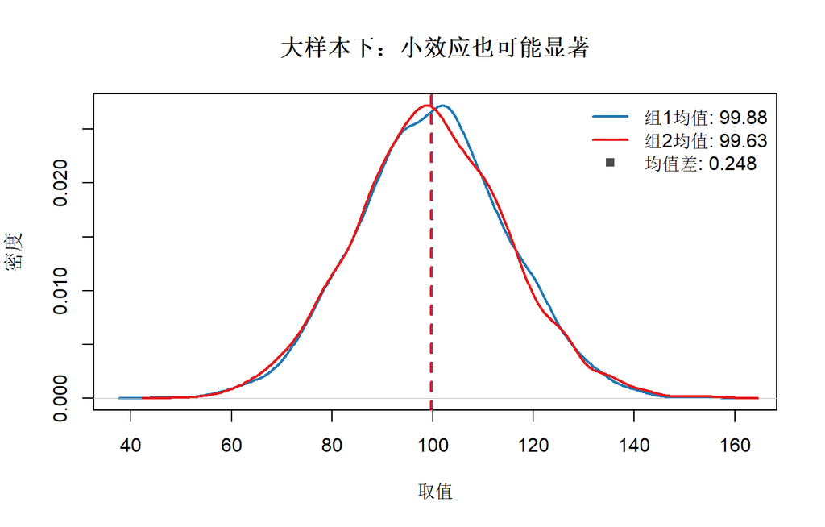

```r
d1 <- density(x1)
d2 <- density(x2)
plot(d1, col = "#1f78b4", lwd = 2,
     main = "大样本下：小效应也可能显著",
     xlab = "取值", ylab = "密度")
lines(d2, col = "#e31a1c", lwd = 2)
abline(v = mean(x1), col = "#1f78b4", lty = 2, lwd = 2)
abline(v = mean(x2), col = "#e31a1c", lty = 2, lwd = 2)
legend("topright",
       legend = c(
         paste0("组1均值: ", round(mean(x1), 2)),
         paste0("组2均值: ", round(mean(x2), 2)),
         paste0("均值差: ", round(m_diff, 3))
       ),
       col = c("#1f78b4", "#e31a1c", "gray30"),
       lwd = c(2, 2, NA), pch = c(NA, NA, 15), bty = "n")
```

# 9 8. 常见误区

1. 把 p 值当成效应大小
2. 只看“显著/不显著”而不看检验方向
3. 不写接受域与判定过程
4. 忽略样本量对显著性的放大作用

# 10 9. 练习任务

1. 将单样本检验改为双侧检验，写出新的接受域并比较结论。
2. 把 A/B 案例样本量减半，观察统计量与判定变化。
3. 为临床两比例案例改写一个左侧检验问题，并给出新的拒绝域。

# 11 章末检查

- 我能写出统计量、临界值、接受域和拒绝域
- 我能根据统计量位置做判定
- 我能解释“样本量变大时更容易显著”这一现象